# proj2

## WRANGLING

1.) There was no missing data in the columns that I chose to represent. Because I natural joined over 3 different data frames, the joins were done on columns that the df’s had in common.

```sql
Select franchName, teamID, yearID, SUM(Salary) as Payroll,W, franchID,G, ((1.0 * W/G) * 100) as Win_percentage
from Salaries natural join Teams natural join TeamsFranchises
where yearID > 1989 and yearID < 2015
group by teamID, yearID
```

```r
payroll_df %>%
  head()
```

```
##                      franchName teamID yearID  Payroll  W franchID   G
## 1                Atlanta Braves    ATL   1990 14555501 65      ATL 162
## 2             Baltimore Orioles    BAL   1990  9680084 76      BAL 161
## 3                Boston Red Sox    BOS   1990 20558333 88      BOS 162
## 4 Los Angeles Angels of Anaheim    CAL   1990 21720000 80      ANA 162
## 5             Chicago White Sox    CHA   1990  9491500 94      CHW 162
## 6                  Chicago Cubs    CHN   1990 13624000 77      CHC 162
##   Win_percentage
## 1       40.12346
## 2       47.20497
## 3       54.32099
## 4       49.38272
## 5       58.02469
## 6       47.53086
```

Q1.)The mean payroll tends to increase over the years. The range of payrolls also increases over the years.

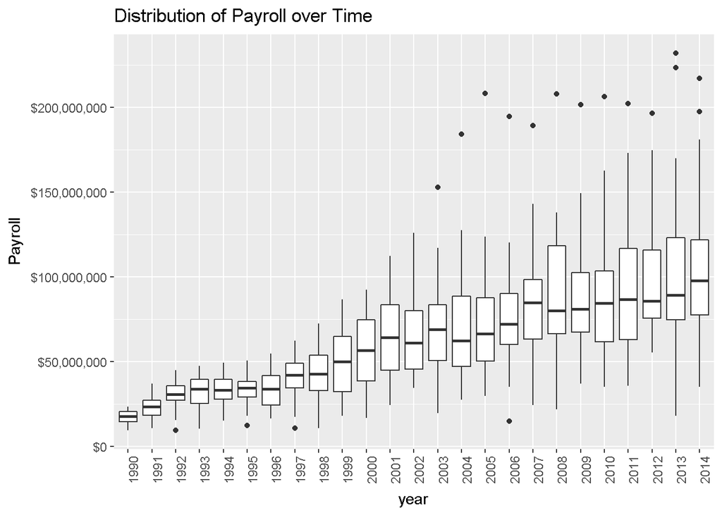

```r
payroll_df_year <- payroll_df%>%mutate(year = factor(yearID))

ggplot(data = payroll_df_year, aes(x = year, y = Payroll)) +
  geom_boxplot() + ggtitle("Distribution of Payroll over Time")  +
  theme(axis.text.x = element_text(angle = 90, hjust = 1)) + scale_y_continuous(labels = scales::dollar)
```

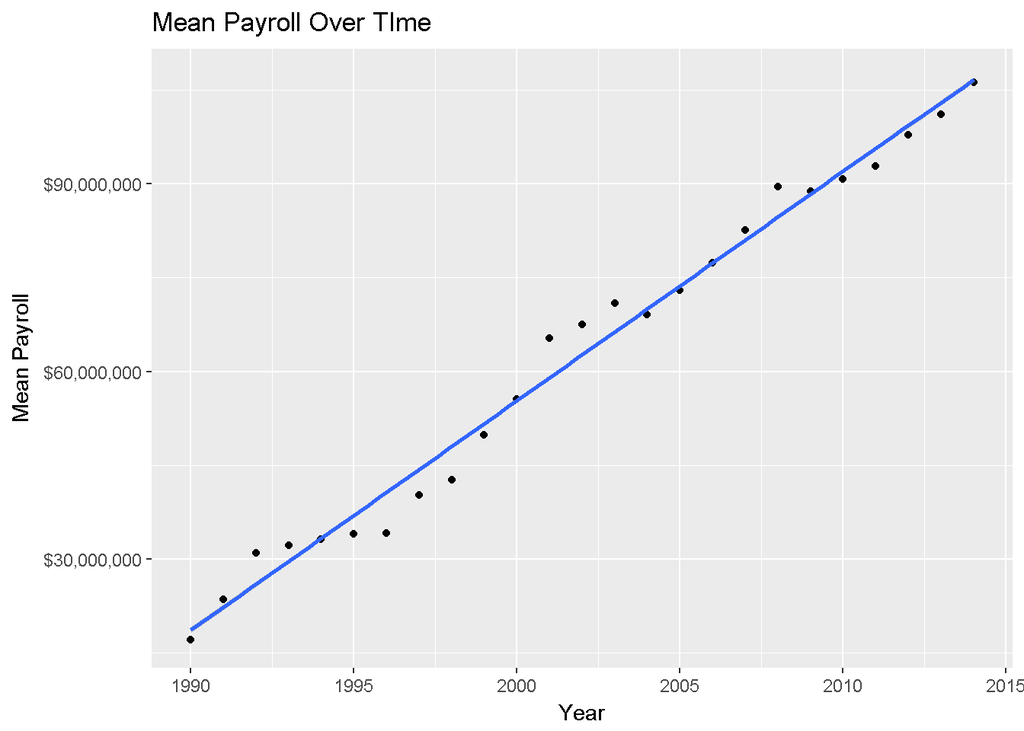

```r
payroll_def_mean <- payroll_df %>%
  group_by(yearID) %>%
  mutate(m = mean(Payroll)) %>%
ggplot(aes(x = yearID, y = m)) +
  geom_point() + ylab("Mean Payroll") + xlab("Year") +ggtitle("Mean Payroll Over TIme") + geom_smooth(method = lm) +
 scale_y_continuous(labels = scales::dollar)
payroll_def_mean
```

Q2.) Team payrolls between 1990-1995 were relatively close together. but by 2000-2004 team’s began investing alot more in their players, most notably the New York Yankees. In the 2000-2004 era, which is also the Moneyball era, the Oakland A’s had an impressive win percentage of aroun 60% yet spent significantly less than the other teams that acheived a similiar winrate (ATL and NYA). However, given the A’s success, other team started catching on in subsequent years and they too started to redefine the value of a baseball player. NYA continued to invest considerable amounts of money into players even after moneyball. Before the moneyball era, it is apparant that spending more on players will net a better win percetnage. However, by analyzing the change in slope of the regression line, it is evident that while this trend of spending more for wins continues over the years, it is not as significant as pre-Moneyball era.

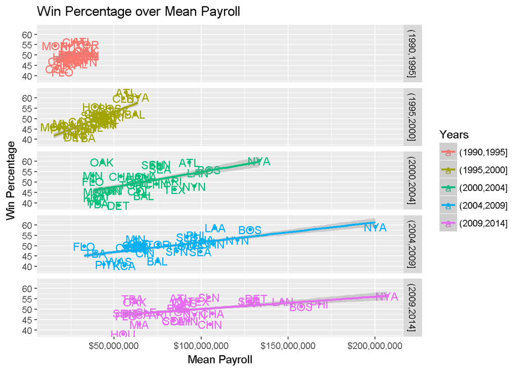

```r
payroll_def_mean <- payroll_df %>%
 mutate(cutted =  cut(yearID, breaks = 5)) %>%
  group_by(cutted, teamID) %>%
  mutate(m = mean(Payroll)) %>%
  mutate(wp = mean(Win_percentage)) %>%
  ggplot(aes(x = m, y = wp, color = factor(cutted))) +
  geom_point() +
  facet_grid(cutted~., space = "free") +
  geom_text(aes(label=teamID)) +
  geom_smooth(method =lm) +
  scale_x_continuous(labels = scales::dollar) +
  labs(title = "Win Percentage over Mean Payroll", x = "Mean Payroll", y = "Win Percentage", color = "Years")
payroll_def_mean
```

Q3.) For problem 4 our payroll variable was an averge(mean) over 5 different 5 year periods, while our payroll varaible for problem 6 was was a standardized payroll variable over 1 year for 1 team.The payroll variable will have a mean of 0 and a standard deviation of 1in problem 6 because it has become standardized. This allows us to compare teams win percentage and payroll based on how they vary from the rest of the data.

```r
u1 <- payroll_df %>%
  group_by(yearID)%>%
  mutate(cutted = cut(yearID, breaks=5))%>%
  mutate(avg_year = mean(Payroll)) %>%
  mutate(std = sd(Payroll))
```

[output not shown]

[output cut: 19 more lines]

[output not shown]

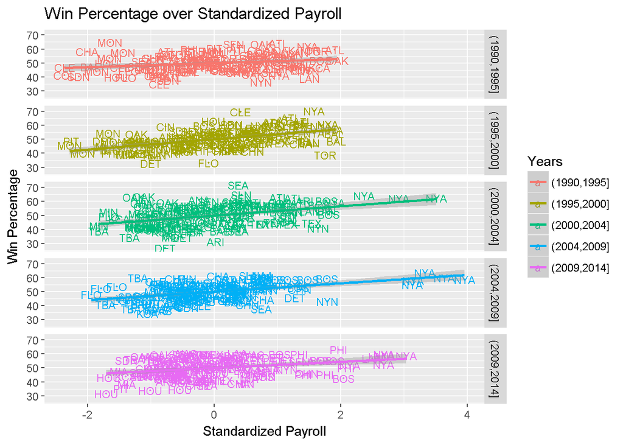

```r
standard <- payroll_df %>% left_join(u1) %>%
  mutate(cutted = cut(yearID, breaks=5)) %>%
  group_by(cutted,teamID) %>%
  group_by(yearID,teamID) %>%
  mutate(standardized_payroll = ((Payroll - avg_year)/std)) %>%
  group_by(cutted,teamID) %>%
  ggplot(aes(x = standardized_payroll, y = Win_percentage, color = factor(cutted))) +
  geom_text(aes(label = teamID), size = 3 ) +
  geom_point(size = .3) +
  geom_smooth(method = lm) +
  facet_grid(cutted~.) +
  labs(title = "Win Percentage over Standardized Payroll", x = "Standardized Payroll", y = "Win Percentage", color = "Years")
standard
```

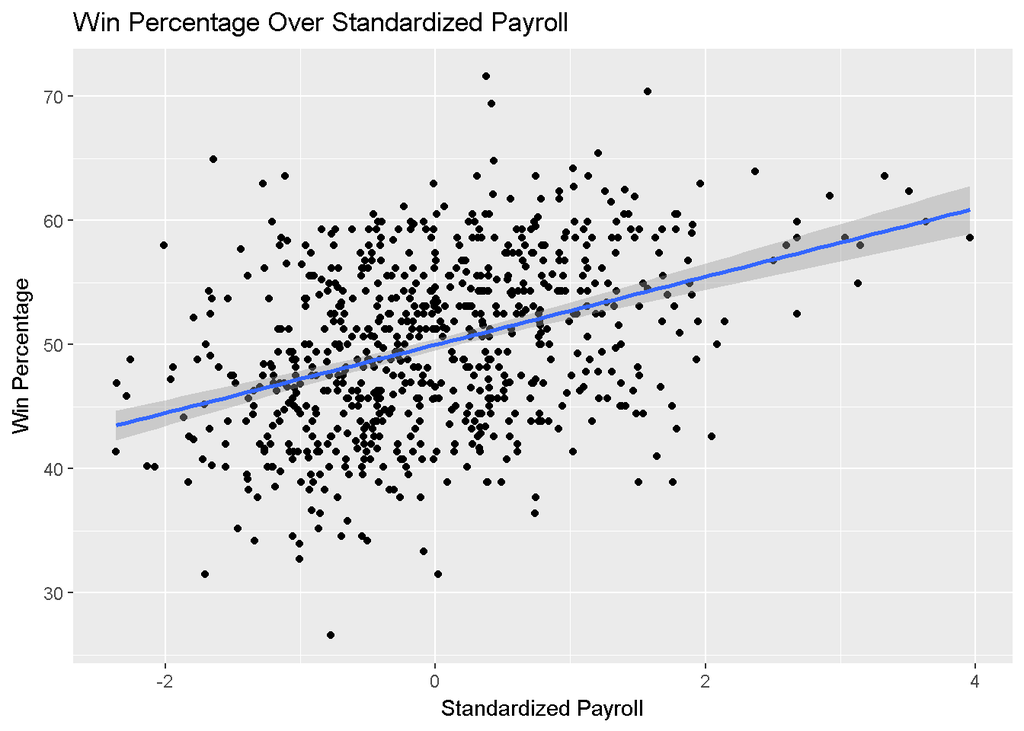

```r
payroll_df %>%
  group_by(yearID) %>%
  mutate(avg_year = mean(Payroll)) %>%
  mutate(standardized = ((Payroll - avg_year)/sd(Payroll))) %>%
  ggplot(aes(x = standardized, y = Win_percentage)) +
  geom_point() + ylab("Win Percentage") + xlab("Standardized Payroll") + ggtitle("Win Percentage Over Standardized Payroll")  +  geom_smooth(method =lm)
```

```r
payroll_df
```

[output not shown]

[output cut: 1443 more lines]

Q4.) Question 2 and 3 deal with win percentage as a function of payroll while for this function, we have efficiency as a function of year. In this plot we are also able to see how a team’s efficiency changes over the years( purpose of a line plot). From this plot we are also able to see the spike that Oakland had during the moneyball period in terms of efficiency, warranting the creation of the movie.

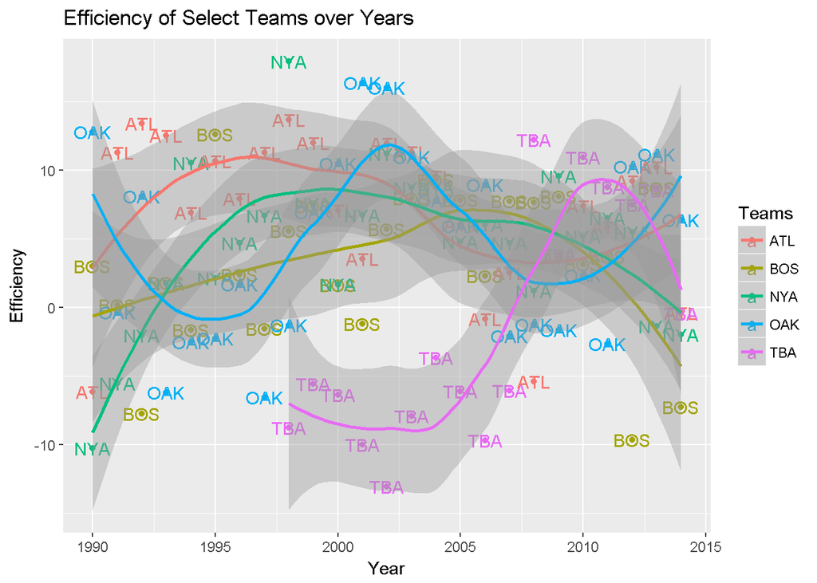

```r
efficiency <- payroll_df %>%
  filter(teamID == "OAK" | teamID == "NYA" | teamID == "BOS" | teamID == "ATL" | teamID == "TBA") %>%
  group_by(yearID) %>%
  mutate(avg_year = mean(Payroll)) %>%
  mutate(standardized = ((Payroll - avg_year)/sd(Payroll))) %>%
  mutate (expected_wp = (50 + 2.5 * (standardized))) %>%
  mutate(efficiency = Win_percentage - expected_wp) %>%
  group_by(teamID) %>%
  ggplot(aes(x = yearID, y = efficiency, color = factor(teamID))) + geom_point() + geom_text(aes(label = teamID)) +
  labs(title = "Efficiency of Select Teams over Years", x = "Year", y = "Efficiency", color = "Teams") + geom_smooth()

efficiency
```